# Data 624 Homework 6

### (c) MA(1)

```r
for(i in 2:100)
  y[i] <- 0.6*y[i-1] + e[i]
fit2<-Arima(y, order=c(0,0,1))
fit2
```

```
## Series: y
## ARIMA(0,0,1) with non-zero mean
##
## Coefficients:
##          ma1    mean
##       0.4419  0.4027
## s.e.  0.0723  0.1629
##
## sigma^2 estimated as 1.31:  log likelihood=-154.48
## AIC=314.97   AICc=315.22   BIC=322.78
```

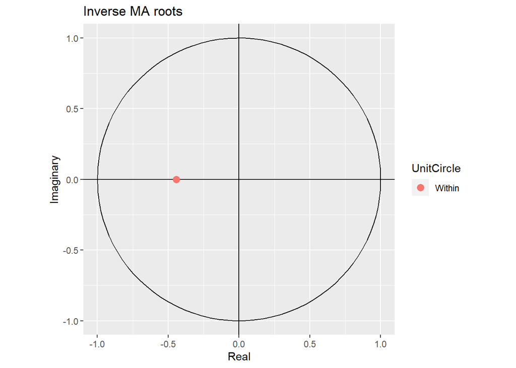

```r
autoplot(fit2)
```

### (d) Time Plot MA(1)

Produce a time plot for the series. How does the plot change as you change θ1?

**Once again, the change to ϕ1 adds a bit of a long-term uptrend to the plot although it is not seasonaly consistent**

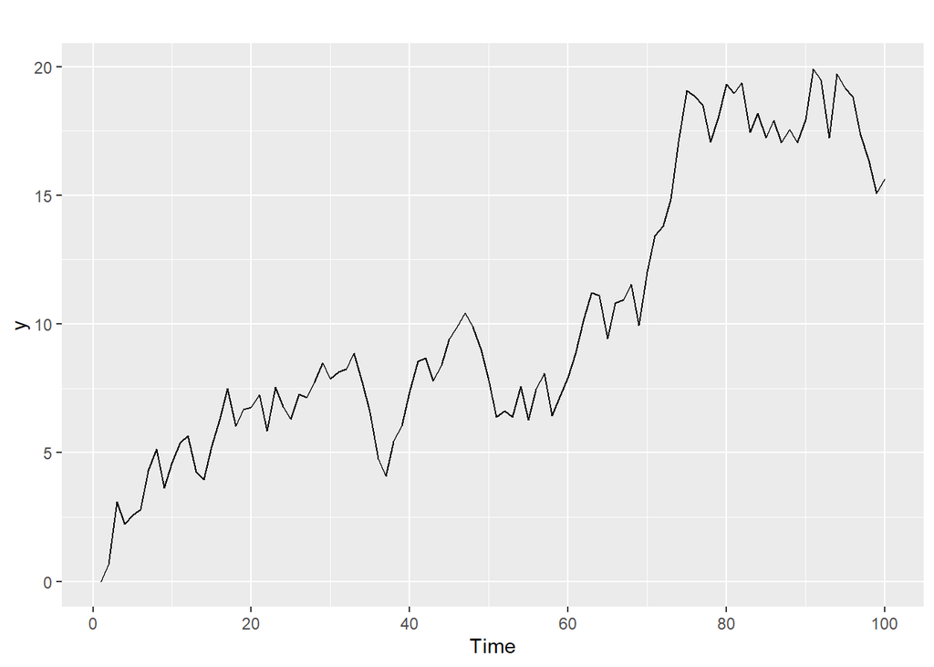

### (e) ARIMA(1,1)

Generate data from an ARMA(1,1) model with ϕ1=0.6 and σ2=1

```r
for(i in 2:100)
  y[i] <- 0.6*y[i-1] + e[i]
fit3<-Arima(y, order=c(1,0,1), include.constant = TRUE)
fit3
```

```
## Series: y
## ARIMA(1,0,1) with non-zero mean
##
## Coefficients:
##          ar1     ma1    mean
##       0.5154  0.0405  0.3867
## s.e.  0.1484  0.1679  0.2310
##
## sigma^2 estimated as 1.217:  log likelihood=-150.39
## AIC=308.77   AICc=309.19   BIC=319.19
```

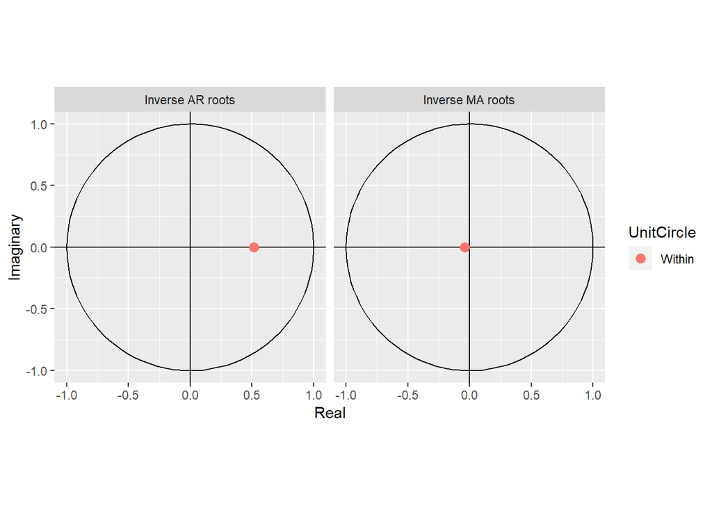

```r
autoplot(fit3)
```

```r
plot1<-autoplot(y)
```

### (f) AR(2)

```r
for(i in 2:100)
  y[i] <- 0.8*y[i-1] + 0.3*y[i-1] +e[i]
fit4<-Arima(y, order=c(2,0,1), include.constant = TRUE)
fit4
```

```
## Series: y
## ARIMA(2,0,1) with non-zero mean
##
## Coefficients:
##          ar1      ar2     ma1      mean
##       1.9995  -0.9995  0.9753  21381.77
## s.e.  0.0007   0.0007  0.0369       NaN
##
## sigma^2 estimated as 3008:  log likelihood=-546.48
## AIC=1102.95   AICc=1103.59   BIC=1115.98
```

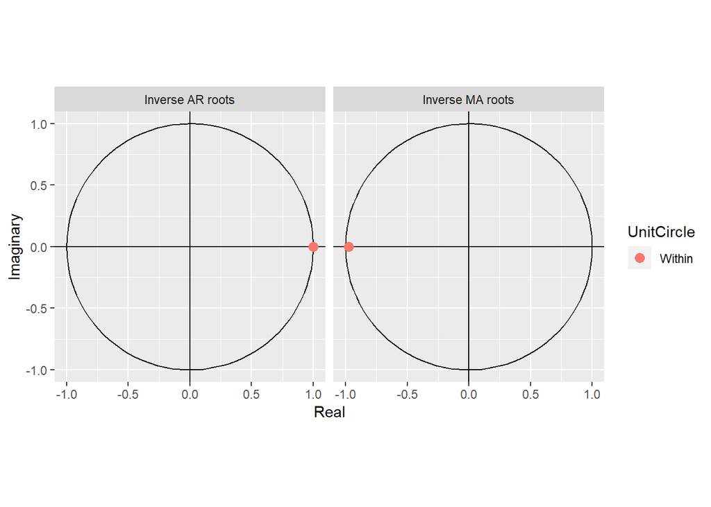

```r
autoplot(fit4)
```

```r
plot2<-autoplot(y)
```

### (g) Graph and Compare

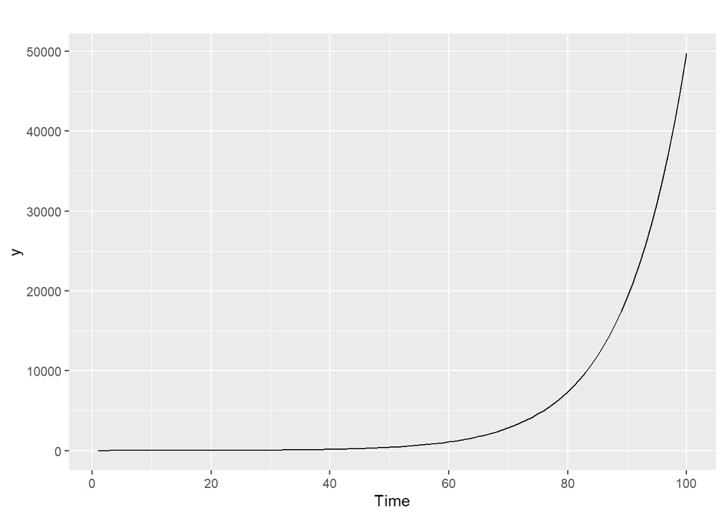

Consider wmurders, the number of women murdered each year (per 100,000 standard population) in the United States.

## 7 Wmurders

### (a) Find ARIMA Model

By studying appropriate graphs of the series in R, find an appropriate ARIMA(p,d,q) model for these data.

**The ACF model shows lags declining show we should use aa ARIMA(p,d,0) model. The auto.arima selects ARIMA(1,2,1) as the model**

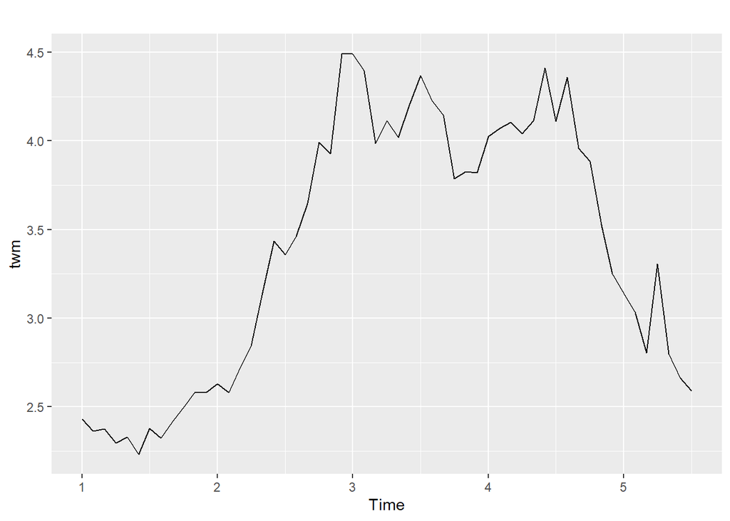

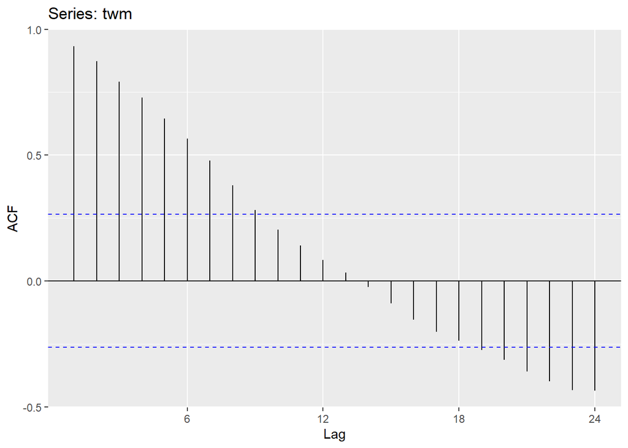

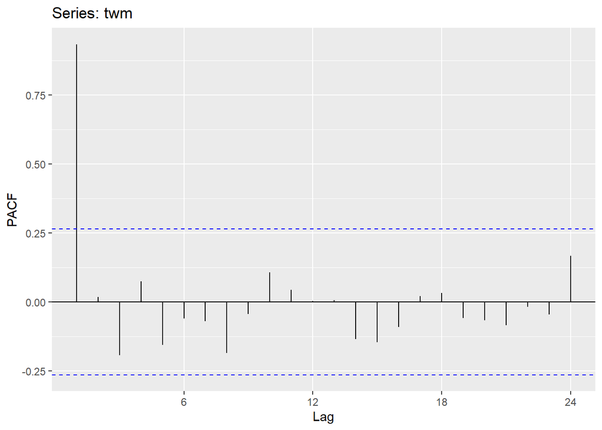

```
## Series: twm
## ARIMA(1,2,1)
##
## Coefficients:
##           ar1      ma1
##       -0.2434  -0.8261
## s.e.   0.1553   0.1143
##
## sigma^2 estimated as 0.04632:  log likelihood=6.44
## AIC=-6.88   AICc=-6.39   BIC=-0.97
```

**The plots of the ts with log, diff and doubdle diff show that 1-2 differences would stabalize the data. Ndiff and NSdiffs confirm there should be 2 diffes and 0 seasonal diffs respectively**

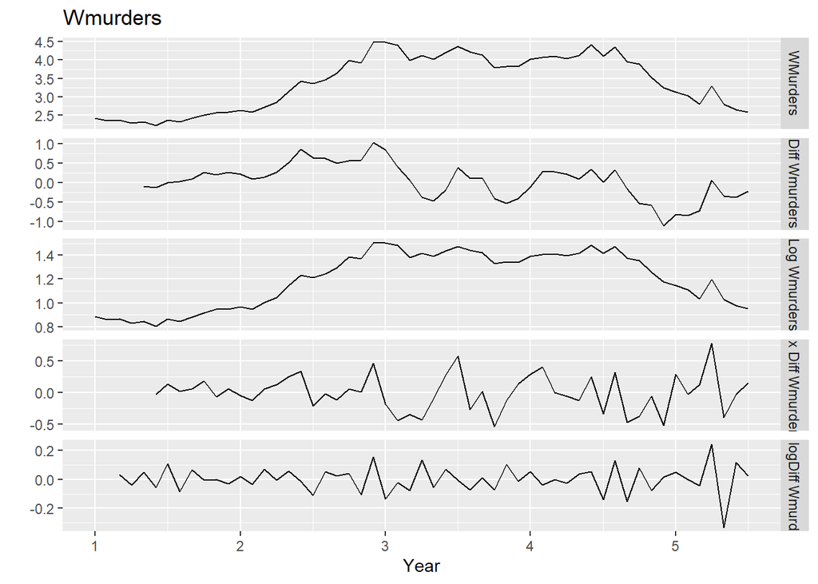

```
##
## #######################
## # KPSS Unit Root Test #
## #######################
##
## Test is of type: mu with 3 lags.
##
## Value of test-statistic is: 0.6331
##
## Critical value for a significance level of:
##                 10pct  5pct 2.5pct  1pct
## critical values 0.347 0.463  0.574 0.739
```

```
##
## #######################
## # KPSS Unit Root Test #
## #######################
##
## Test is of type: mu with 3 lags.
##
## Value of test-statistic is: 0.4697
##
## Critical value for a significance level of:
##                 10pct  5pct 2.5pct  1pct
## critical values 0.347 0.463  0.574 0.739
```

```
## [1] 2
```

```
## [1] 0
```

**Fits with residual checks show fit1 with ARIMA(1,1,2) has lowest ACF.**

```
## Series: log(twm)
## ARIMA(1,1,2)
##
## Coefficients:
##          ar1      ma1     ma2
##       0.1014  -0.1729  0.4023
## s.e.  0.2761   0.2479  0.1911
##
## sigma^2 estimated as 0.003469:  log likelihood=77.67
## AIC=-147.35   AICc=-146.53   BIC=-139.39
```

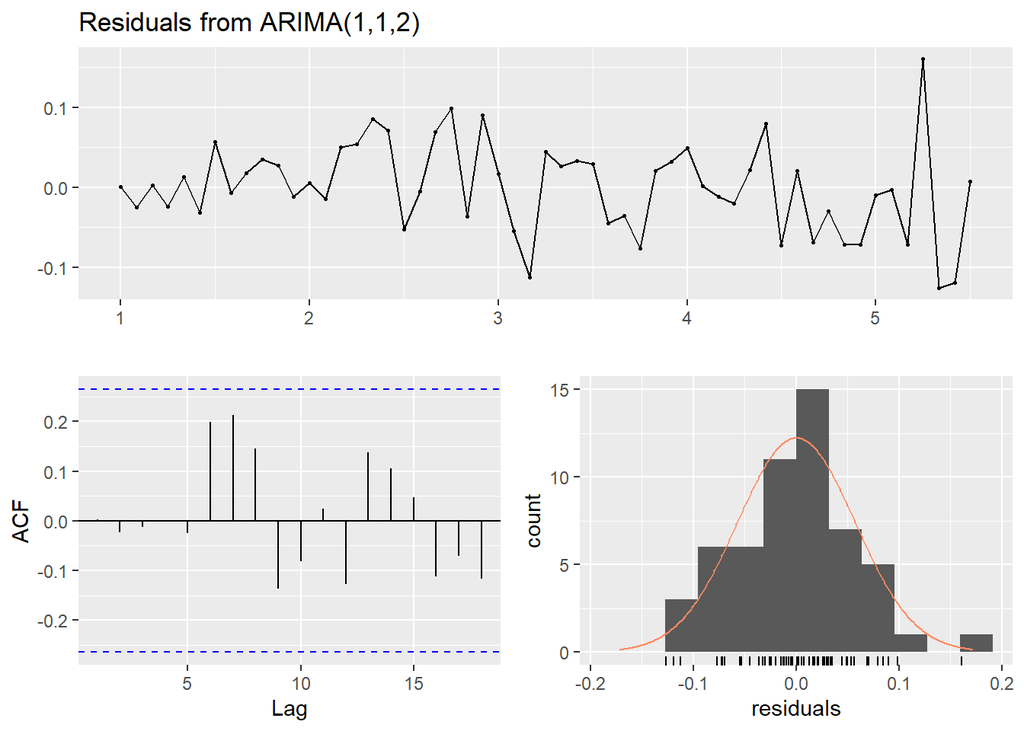

```
##
##  Ljung-Box test
##
## data:  Residuals from ARIMA(1,1,2)
## Q* = 8.7524, df = 8, p-value = 0.3636
##
## Model df: 3.   Total lags used: 11
```

```
## Series: log(twm)
## ARIMA(1,2,2)
##
## Coefficients:
##           ar1      ma1      ma2
##       -0.7427  -0.3057  -0.4482
## s.e.   0.3341   0.4080   0.3919
##
## sigma^2 estimated as 0.003599:  log likelihood=74.67
## AIC=-141.34   AICc=-140.5   BIC=-133.46
```

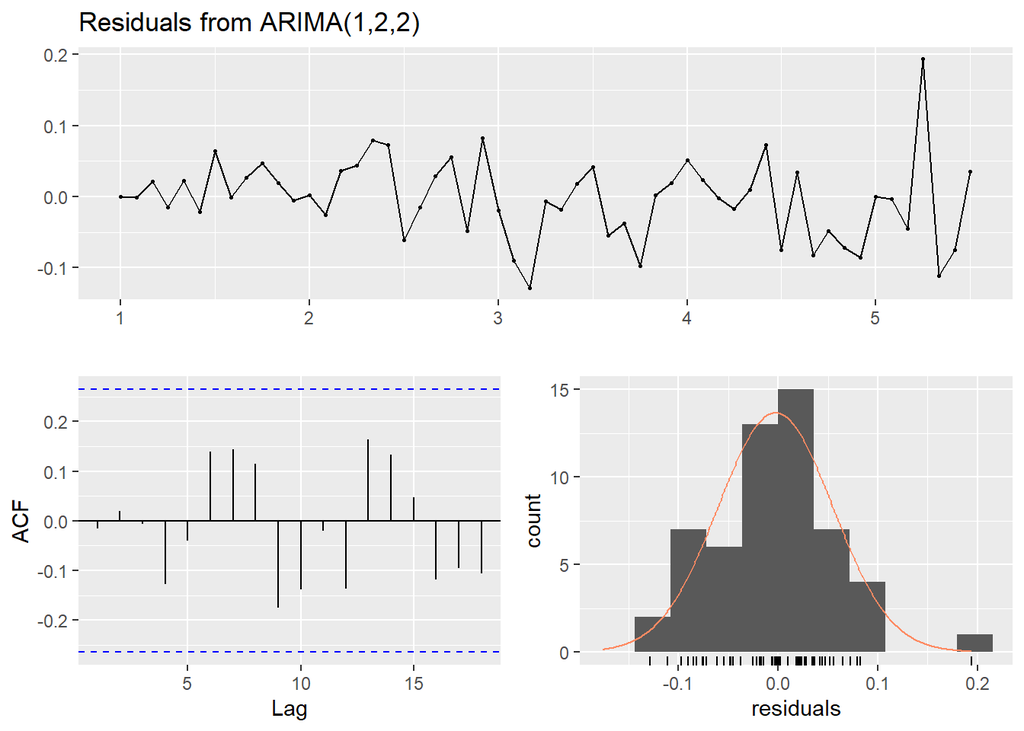

```
##
##  Ljung-Box test
##
## data:  Residuals from ARIMA(1,2,2)
## Q* = 8.0787, df = 8, p-value = 0.4258
##
## Model df: 3.   Total lags used: 11
```

```
## Series: log(twm)
## ARIMA(1,2,1)
##
## Coefficients:
##           ar1      ma1
##       -0.2954  -0.7892
## s.e.   0.1533   0.1190
##
## sigma^2 estimated as 0.003613:  log likelihood=74.09
## AIC=-142.17   AICc=-141.68   BIC=-136.26
```

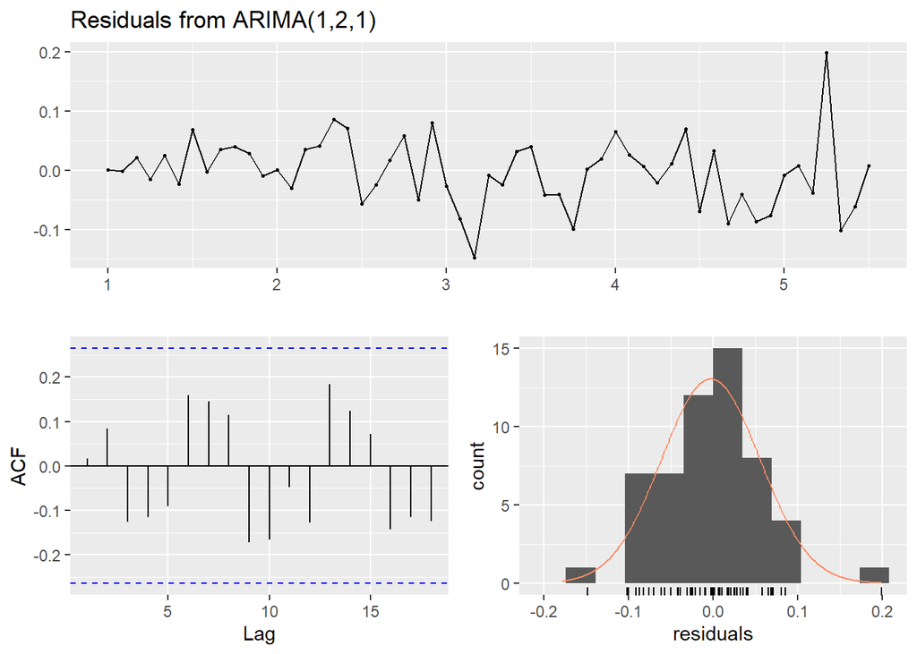

```
##
##  Ljung-Box test
##
## data:  Residuals from ARIMA(1,2,1)
## Q* = 10.73, df = 9, p-value = 0.2947
##
## Model df: 2.   Total lags used: 11
```

### (b) Include Constant

Should you include a constant in the model? Explain.

**When setting constant = TRUE for selected fit1 the AIC is slightly with constant turned on. Therefor, we should NOT include constant**

```r
fit4<- Arima(log(twm), order= c(1,1,2), include.constant = TRUE)
fit4
```

```
## Series: log(twm)
## ARIMA(1,1,2) with drift
##
## Coefficients:
##          ar1      ma1     ma2   drift
##       0.1013  -0.1728  0.4022  0.0001
## s.e.  0.2768   0.2486  0.1916  0.0106
##
## sigma^2 estimated as 0.003538:  log likelihood=77.67
## AIC=-145.35   AICc=-144.1   BIC=-135.4
```

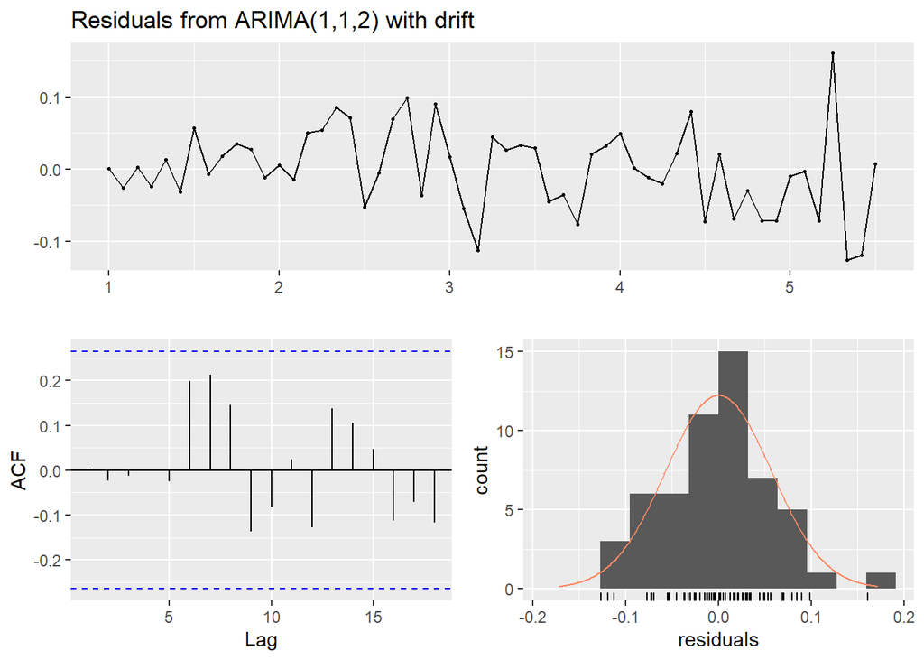

```
##
##  Ljung-Box test
##
## data:  Residuals from ARIMA(1,1,2) with drift
## Q* = 8.7516, df = 7, p-value = 0.271
##
## Model df: 4.   Total lags used: 11
```

```r
checkresiduals(fit4)
```

### (c) Backshift Operator

Write this model in terms of the backshift operator.

```r
fit5<- Arima(log(twm), order= c(1,1,3), seasonal= c(0,0,1))
fit5
```

```
## Series: log(twm)
## ARIMA(1,1,3)(0,0,1)[12]
##
## Coefficients:
##           ar1     ma1     ma2     ma3     sma1
##       -0.1851  0.1432  0.3886  0.1396  -0.1815
## s.e.   0.8467  0.8321  0.1938  0.3991   0.1713
##
## sigma^2 estimated as 0.003494:  log likelihood=78.35
## AIC=-144.69   AICc=-142.9   BIC=-132.76
```

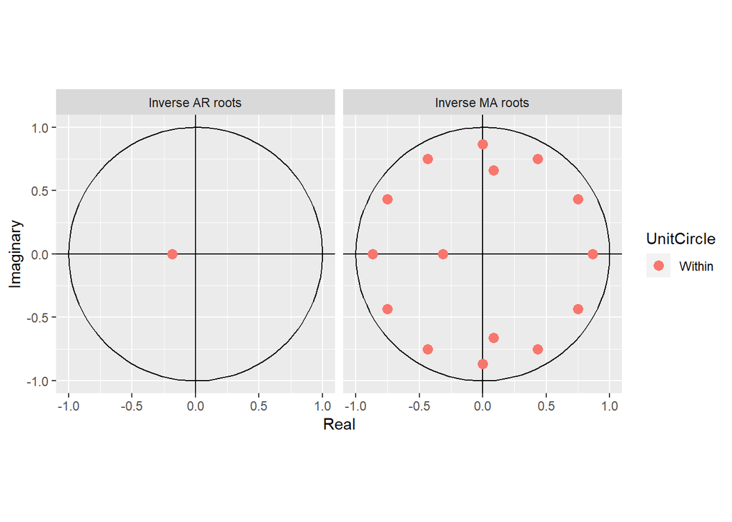

```r
autoplot(fit5)
```

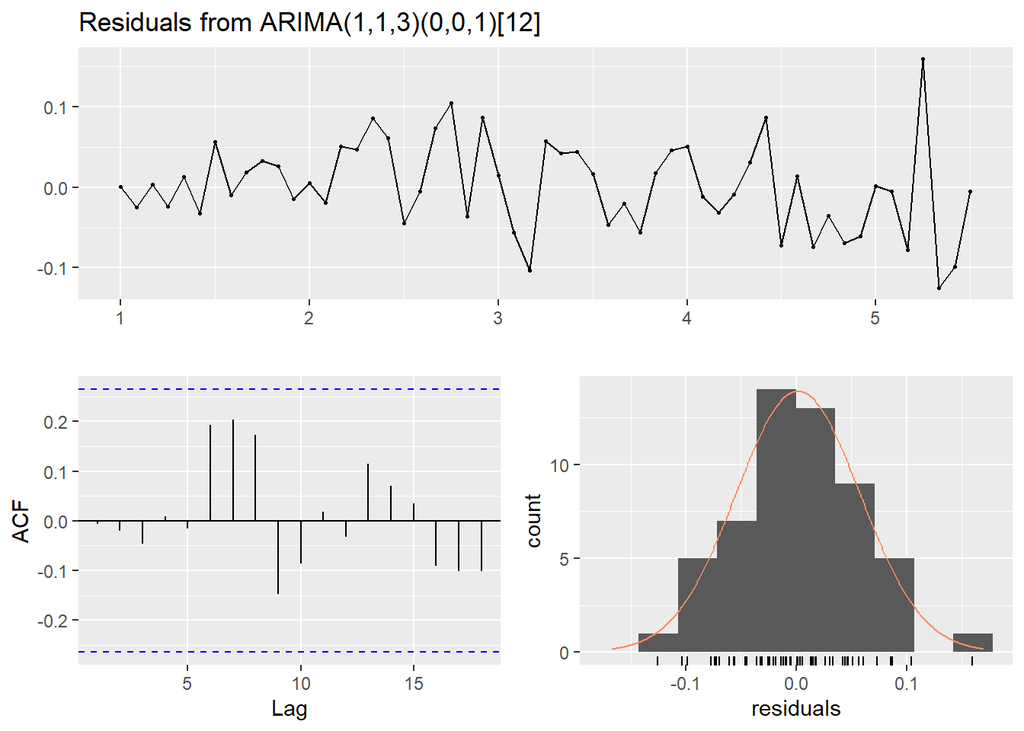

```
##
##  Ljung-Box test
##
## data:  Residuals from ARIMA(1,1,3)(0,0,1)[12]
## Q* = 9.2793, df = 6, p-value = 0.1585
##
## Model df: 5.   Total lags used: 11
```

```r
checkresiduals(fit5)
```

### (d) Examine Residuals

Fit the model using R and examine the residuals. Is the model satisfactory

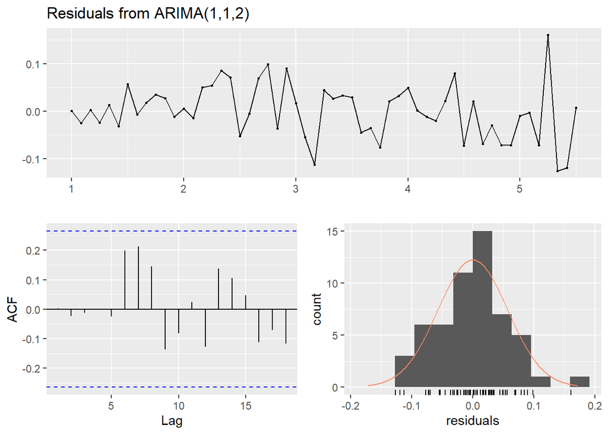

```
##
##  Ljung-Box test
##
## data:  Residuals from ARIMA(1,1,2)
## Q* = 8.7524, df = 8, p-value = 0.3636
##
## Model df: 3.   Total lags used: 11
```

### (e) Forecast

Forecast three times ahead. Check your forecasts by hand to make sure that you know how they have been calculated.

```r
ffit1<-forecast(h=3,fit1)
ffit1
```

```
##       Point Forecast     Lo 80     Hi 80     Lo 95    Hi 95
## Aug 5      0.8993161 0.8238387 0.9747934 0.7838835 1.014749
## Sep 5      0.8970516 0.7940571 1.0000461 0.7395351 1.054568
## Oct 5      0.8968220 0.7533395 1.0403045 0.6773844 1.116260
```

```r
upper <- fitted(fit1) + 1.96*sqrt(fit1$sigma2)
lower <- fitted(fit1) - 1.96*sqrt(fit1$sigma2)
upper
```

```
##         Jan       Feb       Mar       Apr       May       Jun       Jul
## 1 1.0021976 1.0010827 0.9776922 0.9703593 0.9483266 0.9509012 0.9252877
## 2 1.0767625 1.0782150 1.0667314 1.1073994 1.1761637 1.2781993 1.3797627
## 3 1.6008775 1.6510270 1.6103024 1.4852780 1.4803772 1.5174857 1.5599804
## 4 1.4585937 1.5174839 1.5398297 1.5314754 1.5084241 1.5199277 1.6013790
## 5 1.2690963 1.2288638 1.2187199 1.1499233 1.2706081 1.2138904 1.0593507
##         Aug       Sep       Oct       Nov       Dec
## 1 0.9655385 0.9797345 0.9957116 1.0355284 1.0757024
## 2 1.3622532 1.3401220 1.4007896 1.5194449 1.5273218
## 3 1.6018248 1.5735416 1.5238265 1.4365567 1.4241183
## 4 1.5663690 1.5605468 1.5021113 1.4474497 1.3658249
## 5
```

```r
lower
```

```
##         Jan       Feb       Mar       Apr       May       Jun       Jul
## 1 0.7713281 0.7702133 0.7468228 0.7394898 0.7174571 0.7200317 0.6944182
## 2 0.8458930 0.8473456 0.8358619 0.8765299 0.9452942 1.0473299 1.1488932
## 3 1.3700080 1.4201576 1.3794329 1.2544085 1.2495077 1.2866162 1.3291109
## 4 1.2277242 1.2866144 1.3089602 1.3006060 1.2775547 1.2890583 1.3705095
## 5 1.0382269 0.9979943 0.9878504 0.9190538 1.0397386 0.9830210 0.8284812
##         Aug       Sep       Oct       Nov       Dec
## 1 0.7346690 0.7488651 0.7648421 0.8046589 0.8448329
## 2 1.1313837 1.1092526 1.1699201 1.2885754 1.2964523
## 3 1.3709554 1.3426721 1.2929570 1.2056873 1.1932488
## 4 1.3354995 1.3296773 1.2712418 1.2165802 1.1349554
## 5
```

### (f) Plot Forecast

Create a plot of the series with forecasts and prediction intervals for the next three periods shown.

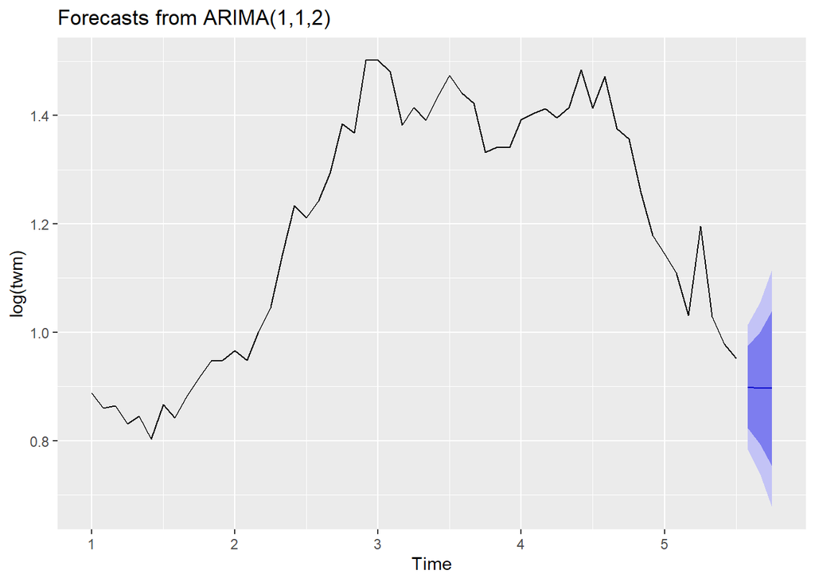

```r
autoplot(forecast(h=3,fit1))
```

### (g) Auto.arima and Conclusion

Does auto.arima() give the same model you have chosen? If not, which model do you think is better?

[output not shown]

## APPENDIX

**Code used in analysis**

```r
knitr::opts_chunk$set(
    echo = FALSE,
    message = FALSE,
    warning = FALSE
)
#knitr::opts_chunk$set(echo = TRUE)
require(knitr)
library(ggplot2)
library(tidyr)
library(MASS)
library(psych)
library(kableExtra)
library(dplyr)
library(faraway)
library(gridExtra)
library(reshape2)
library(leaps)
library(pROC)
library(caret)
library(naniar)
library(pander)
library(pROC)
library(mlbench)
library(e1071)
library(fpp2)
library(urca)
data(ibmclose)
auto.arima(ibmclose)
autoplot(ibmclose)

ggAcf(ibmclose)
ggPacf(ibmclose)

transform<-function (x)
{
compt<-cbind(x=x,
      "log" =log(x),
      "diff" =diff(log(x),12),
      "Double diff"=diff(diff(log(x),12),1))%>%
  autoplot(facets=TRUE)+
  xlab("Year") + ylab("")+
  ggtitle(x)


x %>% diff()%>% ggtsdisplay(main="")
diff(diff(log(x),12),1)%>% ggtsdisplay(main="")

auto.arima(x)
Box.test(x)

checkresiduals(auto.arima(x))

compt
}


transform(usnetelec)
transform(usgdp)
transform(mcopper)
transform(enplanements)
transform(visitors)
retaildata <- readxl::read_excel("retail.xlsx", skip=1)
myts <- ts(retaildata[,"A3349873A"],
  frequency=12, start=c(1982,4))

transform(myts)

checkresiduals(auto.arima(myts))
y <- ts(numeric(100))
e <- rnorm(100)
for(i in 2:100)
  y[i] <- 0.6*y[i-1] + e[i]

autoplot(y)
auto.arima(y)
fit1<-Arima(y, order=c(1,0,0))
fit1
autoplot(fit1)
autoplot(y)
for(i in 2:100)
  y[i] <- 1*y[i-1] + e[i]
#checkresiduals(fit1)
autoplot(y)
for(i in 2:100)
  y[i] <- 0.6*y[i-1] + e[i]
fit2<-Arima(y, order=c(0,0,1))
fit2
autoplot(fit2)
autoplot(y)
for(i in 2:100)
  y[i] <- 1*y[i-1] + e[i]
#checkresiduals(fit1)
autoplot(y)
for(i in 2:100)
  y[i] <- 0.6*y[i-1] + e[i]
fit3<-Arima(y, order=c(1,0,1), include.constant = TRUE)
fit3
autoplot(fit3)
plot1<-autoplot(y)
for(i in 2:100)
  y[i] <- 0.8*y[i-1] + 0.3*y[i-1] +e[i]
fit4<-Arima(y, order=c(2,0,1), include.constant = TRUE)
fit4
autoplot(fit4)
plot2<-autoplot(y)
plot1
plot2
data("wmurders")
twm<-ts(wmurders, frequency = 12)
autoplot(twm)
ggAcf(twm)
ggPacf(twm)
auto.arima(twm)

cbind("WMurders"= twm,
      "Diff Wmurders" = diff(twm,lag=4),
      "Log Wmurders" = log(twm),
      "2 x Diff Wmurders" = diff(diff(twm,lag=4)),
      "2 x logDiff Wmurders" = diff(diff(log(twm))))%>%
        autoplot(facets=TRUE)+
        xlab("Year") + ylab("")+
        ggtitle("Wmurders")

twm %>% ur.kpss() %>% summary
diff(twm) %>% ur.kpss() %>% summary
ndiffs(twm)
nsdiffs(twm)

fit1<- Arima(log(twm), order= c(1,1,2))
fit1
checkresiduals(fit1)
fit2<- Arima(log(twm), order= c(1,2,2))
fit2
checkresiduals(fit2)
fit3<- auto.arima(log(twm))
fit3
checkresiduals(fit3)

fit4<- Arima(log(twm), order= c(1,1,2), include.constant = TRUE)
fit4
checkresiduals(fit4)

fit5<- Arima(log(twm), order= c(1,1,3), seasonal= c(0,0,1))
fit5
autoplot(fit5)
checkresiduals(fit5)



checkresiduals(fit1)
ffit1<-forecast(h=3,fit1)
ffit1

upper <- fitted(fit1) + 1.96*sqrt(fit1$sigma2)
lower <- fitted(fit1) - 1.96*sqrt(fit1$sigma2)
upper
lower
autoplot(forecast(h=3,fit1))

m1AIC <- AIC(fit1)
m1BIC <- BIC(fit1)
m2AIC <- AIC(fit2)
m2BIC <- BIC(fit2)
m3AIC <- AIC(fit3)
m3BIC <- BIC(fit3)
m4AIC <- AIC(fit4)
m4BIC <- BIC(fit4)
m5AIC <- AIC(fit5)
m5BIC <- BIC(fit5)
```